# EPID 600 Project Template

Todd Miano

### Overview

My project is focused on prevention of venous thromboembolism (blood clots) in patients after traumatic injury. Trauma patients are at very high risk of developing VTE, with rates ranging from 20-50% in the absence of prophylaxis. Low molecular weight heparin anticoagulants are use to prevent VTE in this population and are effective when given appropriately. However, studies have shown that many trauma patients receive delayed and/or inconsistent administration of prophylaxis. Failure to administer effective prophylaxis may substantially increase VTE risk. Thus, the aim of my project is to examine the association between prophylaxis patterns and VTE risk. I will conduct the project in a cohort of adult trauma patients admitted to the Hospital of the University of Pennsylvania from 2004 to 2014. I have previously constructed this cohort for other research projects. I obtained data on these patients from two sources: 1) the HUP trauma registry; and 2) Penn Data Store, a Penn supported data warehouse. I met with the following faculty members to discuss my project: 1. Robert Gross, MD, MSCE- expert in pharmacoepidemiology and medication adherence; 2. Doug Cines, MD- expert in hematology and venous thrombosis; 3. Sean Hennessy, PharmD, PhD- expert in pharmacoepidemiology and the use of electronic health record data to study drug effects.

I discussed the conceptual framework for thinking about missed doses in my study population with Dr. Gross. In addition, we discussed several different metrics for quantifying missed doses. In particular, he suggested that examining the “longest gap between doses”–detailed below, might be of particular relevance given the pharmacodynamics of enoxaparin anticoagulation. I discussed the dynamics of clot propagation in trauma patients with Dr. Cines. He suggested that the “gap” between doses should not start until >= 24 hours has elapsed between doses, given the half life of enoxaparin. Lastly, Dr. Hennessy highlighted the time course of VTE occurence in this population and advised me to incorporate study methods to ensure that patients with prevalent (i.e. pre-existing at the time of admission) VTE events are not included in the study population (detailed below in the methods section.)

##### Link to github repository

[Final_project_miano](https://github.com/tmiano81/final_project)

### Introduction

Traumatic injury is a major public health problem. It accounts for more than 180,000 deaths, 2.5 million hospitalizations, and $406 billion in medical care and lost productivity each year (1). Importantly, much of the burden associated with trauma occurs well after the acute event. Venous thromboembolism (VTE) is the 4th most common complication in trauma patients (2), representing a major source of preventable morbidity and mortality. In patients who survive the initial 24 hours after injury, pulmonary embolism (PE) is the 3rd leading cause of death (3). Thus, providing effective VTE prophylaxis continues to be a major priority in this population. National guidelines recommend low molecular weight heparin (LMWH) as the first line agent for pharmacologic prophylaxis after traumatic injury (4,5). Despite standard LMWH prophylaxis regimens, VTE remains common, with an incidence ranging from 6-15% (6,7) If VTE rates are to be reduced, we must gain a better understanding of the reasons for LMWH failure in this cohort. Importantly, administration of prophylaxis is frequently delayed or interrupted in this population, as the result of bleeding concerns, the need for surgical intervention, patient refusal, and inadequate risk stratification. Although treatment interuptions may increase VTE risk, the burden of VTE due to this potential risk factor is unclear.

**Therefore, the aim of this project is to:**

Examine the relation between prophylaxis administration patterns and VTE risk after traumatic injury –Hypothesis: early administration patterns will have the strongest effect on VTE risk

### Methods

**Data sources** The data used for this project were obtained from two sources: 1) the HUP trauma registry, which collects data on injury characteristics, injury severity, and complications (including VTE); and 2) Penn Data Store, a Penn supported data warehouse that contains discharge diagnosis codes, laboratory information, and medication administration data. VTE events were identified via query of the trauma registry and query of ICD-9 discharge diagnosis codes. All events identified in this step were validated with manual chart review. Validated events required radiographic confirmation of the VTE event in the electronic medial record. The dataset for the current analysis was previously constructed for other study aims using Stata. The steps required for construction of the dataset included: cleaning trauma registry file; cleaning PDS data files (labs, anticoagulation exposure, determination of enoxaparin prophylaxis exposure and missed dose metrics); merging registry and PDS files; outcome validation.

```r
#Let's download the dataset file from Github
library(RCurl)
library(dplyr)
```

```r
library(ggplot2)
library(lmtest)
final_project.url <- getURL("https://raw.githubusercontent.com/tmiano81/final_project/master/vteMiss_final.csv")
vte <- read.csv(text = final_project.url, header=TRUE)

str(vte)
```

```
## 'data.frame':    3358 obs. of  30 variables:
##  $ pid          : int  1 2 3 4 5 6 7 8 9 10 ...
##  $ age          : num  57 50 38 21 32 89 38 55 18 37 ...
##  $ iss          : int  9 13 10 26 10 5 10 18 4 9 ...
##  $ hr           : int  112 75 87 76 68 86 107 76 77 100 ...
##  $ sbp          : int  NA 158 112 148 158 151 142 127 199 133 ...
##  $ hemoglobin   : num  13.5 11.4 9.65 11.5 12.4 ...
##  $ platelets    : num  182 248 237 176 230 ...
##  $ creatinine   : num  1.2 1 1 1.1 1.3 0.8 1 1 1.1 1 ...
##  $ mLapse       : num  48 24 16 13.3 12 ...
##  $ pVte         : int  0 0 0 0 0 0 0 0 0 0 ...
##  $ delay        : num  3.257 3.401 0.335 1.053 0.774 ...
##  $ early        : num  0 1 0 0 1 1 0 0 0 0 ...
##  $ percentEarly : num  42.9 25 0 0 0 ...
##  $ percentTotal : num  52.6 25 0 0 0 ...
```

[output cut: 16 more lines]

#### The data dictionary for this dataset can be found [here](https://github.com/tmiano81/final_project)

**Using the data dictionary definitions, I will create a new dataframe with appropriate factor variables for analysis**

```r
vte2 <- vte %>%      #Create new dataframe with new factor variables for analysis
  mutate(pVte = factor(pVte, levels=c(0, 1), labels=c("no", "yes"))) %>%
  mutate(scd = factor(scd, levels=c(0, 1), labels=c("no", "yes"))) %>%
  mutate(tbi = factor(tbi, levels=c(0, 1), labels=c("no", "yes"))) %>%
  mutate(a_vent = factor(a_vent, levels=c(0, 1), labels=c("no", "yes"))) %>%
  mutate(aBlood = factor(aBlood, levels=c(0, 1), labels=c("no", "yes"))) %>%
  mutate(or24 = factor(or24, levels=c(0, 1), labels=c("no", "yes"))) %>%
  mutate(femur = factor(femur, levels=c(0, 1), labels=c("no", "yes"))) %>%
  mutate(pelvis = factor(pelvis, levels=c(0, 1), labels=c("no", "yes"))) %>%
  mutate(spine = factor(spine, levels=c(0, 1), labels=c("no", "yes"))) %>%
  mutate(lungContusion = factor(lungContusion, levels=c(0, 1), labels=c("no", "yes"))) %>%
  mutate(bleed = factor(bleed, levels=c(0, 1), labels=c("no", "yes"))) %>%
  mutate(vein = factor(vein, levels=c(0, 1), labels=c("no", "yes"))) %>%
  mutate(artery = factor(artery, levels=c(0, 1), labels=c("no", "yes"))) %>%
  mutate(chronic = factor(chronic, levels=c(1, 0), labels=c("no", "yes"))) %>%
  mutate(icu = factor(icu, levels=c(0, 1), labels=c("no", "yes"))) %>%
  mutate(sex = factor(sex, levels=c(0, 1), labels=c("female", "male"))) %>%
  mutate(race = factor(race, levels=c(1, 2, 3, 4), labels=c("white", "black", "asian", "other")))

##Now, lets count missing values##
sapply(vte2, function(x) length(x[is.na(x)]))
```

```
##           pid           age           iss            hr           sbp
##             0             0            81            52            98
##    hemoglobin     platelets    creatinine        mLapse          pVte
##            45            38            42             0             0
##         delay         early  percentEarly  percentTotal           scd
##             0             0             0             0             0
##           tbi        a_vent        aBlood          or24         femur
##             0            82             0             0             0
##        pelvis         spine lungContusion         bleed          vein
##             0             0             0             0             0
##        artery       chronic           icu          race           sex
##             0             0             0             2             3
```

```r
##Keep complete cases for analysis
vte2<-vte2[complete.cases(vte2), ]

#The dataset is now ready for the main analysis
```

**Study Design and population** This is a retrospective cohort study of patients admitted to the Hospital of the University of Pennsylvania from January 2004 to October 2014 within 24 hours of their injury. Additionally, patients must have been at least 18 years of age, remained alive and in the hospital for at least 24 hours, and received at least 24 hours of thromboprophylaxis with the regimen enoxaparin 30 mg subcutaneously every 12 hours. Patients were excluded if they received any other type of pharmacologic thromboprophylaxis, if they received treatment doses of anticoagulation for any indication other than treatment of incident venous thromboembolism, if they were being treated for active VTE upon admission, or if they were diagnosed with new VTE within 24 hours of admission.

**Primary Exposure variable: non-administration of VTE prophylaxis (i.e. missed doses)** The key variable that will be explored in this analysis is the duration of time during which prophylaxis was not administered during hospitalziation. The specific metrics used to quantify this “non-administration” include:

**1) Cumulative percentage of doses missed-** defined as the cumulative number of missed doses / cumulative number of expected doses. Because enoxaparin is given every 12 hours, the expected number of doses was defined as 2 x (hospital length of stay).

**2) Early missed doses-** the cumulative percentage of missed doses during the first 4 days of a prophylaxis course.

**3) Longest gap between doses-** defined as the longest duration of time in hours between consecutive doses.

**4) Time to first dose (i.e. delay of initiation)-** defined as the duration of time in hours from hospital admission to initiation of the first prophylaxis dose.

**5) Early discontinuation-** defined as the duration of time in hours from the last dose to the end of follow-up.

**Outcome definition and follow-up** The primary outcome is the incidence of VTE, defined as the composite of pulmonary embolism and lower extremity deep venous thrombosis. Patients will enter the cohort after the initial 24 hours of hospitalization and will contribute person time until one of the following: occurence of VTE, hospital discharge, or death.

**Potential confounders** The dataset includes several variables that are risk factors for VTE and thus may be confounding variables. These include age, injury severity score, specific injuries (femur fracture, pelvis fracture, spinal cord injury, major hemorrhage, traumatic brain injury, pulmonary contusion, venous injury, arterial injury), race, gender, admission lab values (creatinine, platelets, hemoglobin), intensive care unit admission, need for operative intervention within 24 hours of admission, vital signs (heart rate, systolic blood pressure), gender, race, and presence of any chronic comorbid illness (heart failure, diabetes mellitus type II, stroke, COPD, chronic kidney disease, chronic liver disease, coronary heart disease, malignancy), need for mechanical ventilation, and need for blood transfusions.

**Data analysis** Associations with VTE will be examined in univatiate analysis with univariate logistic regression. Variables with univariate associations <=0.05 will be included in a multivariable logistic regression model. Multivariable models will be reduced using backwards stebwise selection, with variables that retain signficance at the 0.05 level retained in the model

### Results

```r
##Let's see what the incidence of the primary outcome is in the population
r<-xtabs(~vte2$pVte)
r
```

```
## vte2$pVte
##   no  yes
## 2982   97
```

```r
prop.table(r)
```

```
## vte2$pVte
##         no        yes
## 0.96849627 0.03150373
```

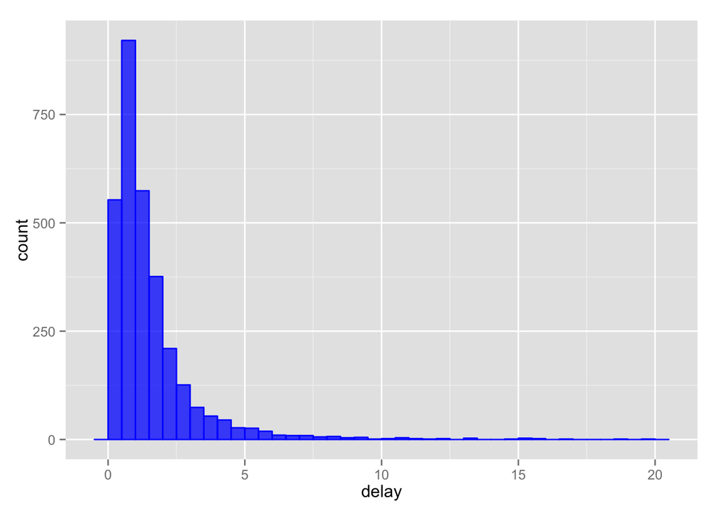

```r
#############################################
##Lets explore the primary exposure variables
#############################################

###############Delay########################
qplot(delay, data=vte2, geom="histogram", col=I("blue"), fill=I("blue"),alpha=I(0.75), binwidth =.5)
```

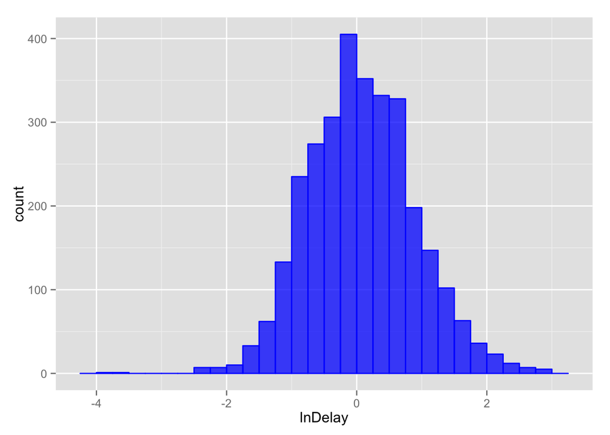

```r
##Distribution is very skewed

#Log transform to better approximate normal distribution
vte2 <- vte2 %>%
  mutate(lnDelay = log(delay))

#transformed variable has more normal distribution
qplot(lnDelay, data=vte2, geom="histogram", col=I("blue"), fill=I("blue"),alpha=I(0.75), binwidth =.25)
```

```r
#In addition, create categorical version of the variable
vte2$dCat <- cut(vte2$delay, breaks=c(0, 1, 2, 3, Inf), labels=c("< 1 day", "1-2 days", "2-3 days", ">3 days"))

#Let's check our work, by looking at the values at each level of the categorical variable
vte2 %>%
  group_by(dCat) %>%
  summarise(
    min_delay = min(delay),
    avg_delay = mean(delay),
    max_delay = max(delay),
    num = n())
```

```
## Source: local data frame [4 x 5]
##
##       dCat min_delay avg_delay  max_delay   num
##     (fctr)     (dbl)     (dbl)      (dbl) (int)
## 1  < 1 day  0.018750  0.601069  0.9993055  1474
## 2 1-2 days  1.000694  1.434559  2.0000000   951
## 3 2-3 days  2.002778  2.428364  2.9979170   335
## 4  >3 days  3.002778  5.309851 19.7583300   319
```

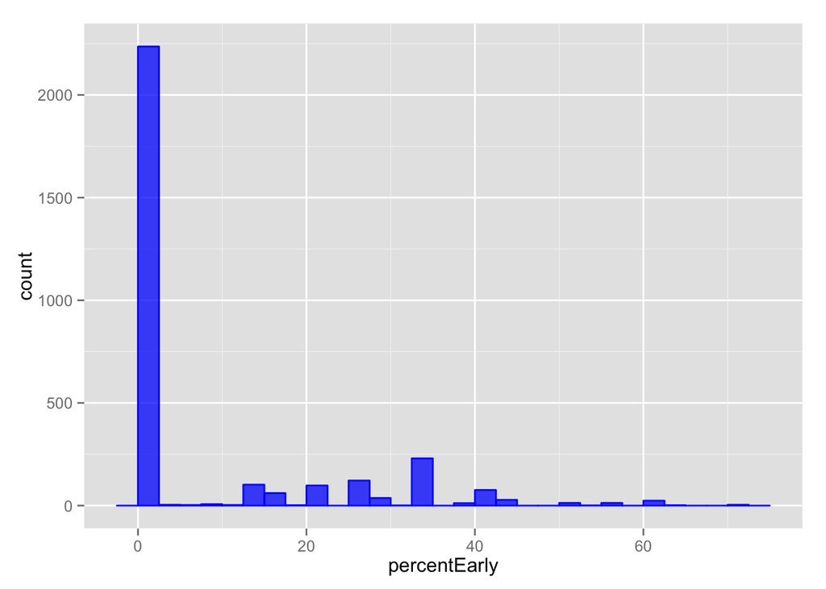

```r
###As you will see in the following analyses, the values for remaining exposure variables take on a limited range of values and thus are not really continuous in nature. I will also convert these to categorical variables.

##################percentEarly###################
qplot(percentEarly, data=vte2, geom="histogram", col=I("blue"), fill=I("blue"),alpha=I(0.75), binwidth =2.5)
```

```r
#very skewed distribution, with the majority of values being zero. Doesn't make sense to model this as continuous.

#Create categorical variable
vte2$earlyMiss <- cut(vte2$percentEarly, breaks=c(-1, 1, 25, Inf), labels=c("Zero", "1-25 %", ">25 %"))

#Let's check our work, by looking at the values at each level of the categorical variable
vte2 %>%
  group_by(earlyMiss) %>%
  summarise(
    min = min(percentEarly),
    avg = mean(percentEarly),
    max = max(percentEarly),
    num = n())
```

```
## Source: local data frame [3 x 5]
##
##   earlyMiss       min      avg      max   num
##      (fctr)     (dbl)    (dbl)    (dbl) (int)
## 1      Zero  0.000000  0.00000  0.00000  2235
## 2    1-25 %  2.409639 18.78067 25.00000   401
## 3     >25 % 26.086960 37.91891 71.42857   443
```

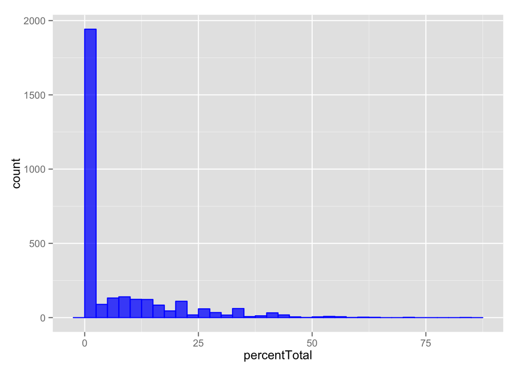

```r
##############percentTotal###############
qplot(percentTotal, data=vte2, geom="histogram", col=I("blue"), fill=I("blue"),alpha=I(0.75), binwidth =2.5)
```

```r
#As with above variable, very skewed with many "zero" values

#Create categorical variable
vte2$totalMiss <- cut(vte2$percentTotal, breaks=c(-1, 1, 25, Inf), labels=c("Zero", "1-25 %", ">25 %"))

#Let's check our work, by looking at the values at each level of the categorical variable
vte2 %>%
  group_by(totalMiss) %>%
  summarise(
    min = min(percentTotal),
    avg = mean(percentTotal),
    max = max(percentTotal),
    num = n())
```

```
## Source: local data frame [3 x 5]
##
##   totalMiss       min          avg        max   num
##      (fctr)     (dbl)        (dbl)      (dbl) (int)
## 1      Zero  0.000000 3.756546e-04  0.7246377  1929
## 2    1-25 %  1.449275 1.221387e+01 25.0000000   909
## 3     >25 % 25.531920 3.692777e+01 82.6087000   241
```

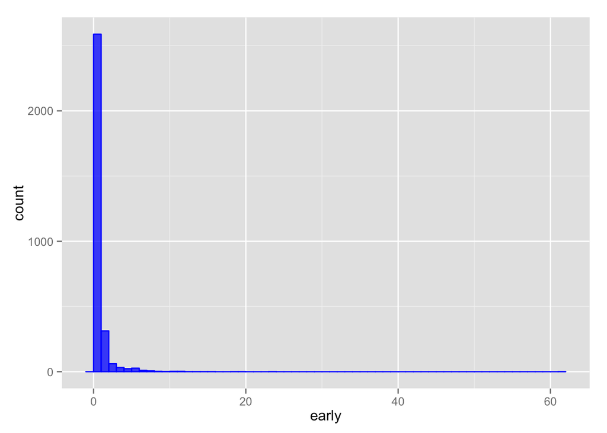

```r
##############Early Discontinuation##################
qplot(early, data=vte2, geom="histogram", col=I("blue"), fill=I("blue"),alpha=I(0.75), binwidth =1)
```

```r
#Create categorical variable
vte2$earlyDc <- cut(vte2$early, breaks=c(-1, 0, 1, Inf), labels=c("None", "1 day early %", ">1 day early %"))

#Let's check our work, be looking at the values at each level of the categorical variable
vte2 %>%
  group_by(earlyDc) %>%
  summarise(
    min = min(early),
    avg = mean(early),
    max = max(early),
    num = n())
```

```
## Source: local data frame [3 x 5]
##
##          earlyDc   min       avg   max   num
##           (fctr) (dbl)     (dbl) (dbl) (int)
## 1           None   0.0 0.0000000     0  2576
## 2  1 day early %   0.1 0.9667692     1   325
## 3 >1 day early %   2.0 4.6460674    61   178
```

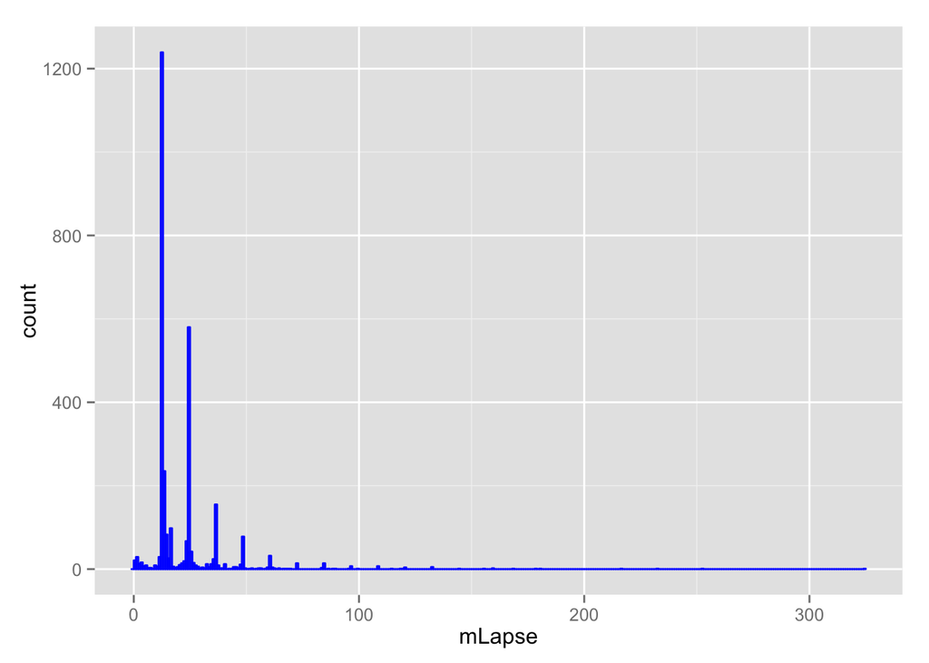

```r
###############Longest Gap#################
qplot(mLapse, data=vte2, geom="histogram", col=I("blue"), fill=I("blue"),alpha=I(0.75), binwidth =1)
```

```r
#Create categorical variable
vte2$lapse <- cut(vte2$mLapse, breaks=c(-1, 24, 48, Inf), labels=c("< 24 hours", "24-48 hours", ">48 hours"))

#Let's check our work, be looking at the values at each level of the categorical variable
vte2 %>%
  group_by(lapse) %>%
  summarise(
    min = min(mLapse),
    avg = mean(mLapse),
    max = max(mLapse),
    num = n())
```

```
## Source: local data frame [3 x 5]
##
##         lapse      min      avg   max   num
##        (fctr)    (dbl)    (dbl) (dbl) (int)
## 1  < 24 hours  0.00000 14.95882    24  2435
## 2 24-48 hours 24.01667 34.25081    48   497
## 3   >48 hours 48.06667 83.21542   324   147
```

```r
####Now, examine associations of exposure variables with outcome#######

###############Delay#################
##Log transformed version
glm <- glm(pVte ~ lnDelay, family = binomial(), data=vte2)
exp(summary(glm)$coeff[-1,1]) #Odds ratio
```

```
## [1] 2.131423
```

```r
summary(glm)$coeff[-1,4] #p-value
```

```
## [1] 4.21975e-10
```

```r
##Categorical version
xtabs(~vte2$pVte+ vte2$dCat)
```

```
##          vte2$dCat
## vte2$pVte < 1 day 1-2 days 2-3 days >3 days
##       no     1455      919      314     294
##       yes      19       32       21      25
```

```r
glm <- glm(pVte ~ dCat, family = binomial(), data=vte2)
exp(summary(glm)$coeff[-1,1]) #Odds ratio
```

```
## dCat1-2 days dCat2-3 days  dCat>3 days
##     2.666514     5.121522     6.511815
```

```r
summary(glm)$coeff[-1,4] #p-value
```

```
## dCat1-2 days dCat2-3 days  dCat>3 days
## 8.049250e-04 4.145827e-07 1.696094e-09
```

```r
###############percentEarly#################
xtabs(~vte2$pVte+ vte2$earlyMiss)
```

```
##          vte2$earlyMiss
## vte2$pVte Zero 1-25 % >25 %
##       no  2168    393   421
##       yes   67      8    22
```

```r
glm <- glm(pVte ~ earlyMiss, family = binomial(), data=vte2)
exp(summary(glm)$coeff[-1,1]) #Odds ratio
```

```
## earlyMiss1-25 %  earlyMiss>25 %
##       0.6586913       1.6909278
```

```r
summary(glm)$coeff[-1,4] #p-value
```

```
## earlyMiss1-25 %  earlyMiss>25 %
##      0.26942943      0.03669243
```

```r
###############percentTotal#################
xtabs(~vte2$pVte+ vte2$totalMiss)
```

```
##          vte2$totalMiss
## vte2$pVte Zero 1-25 % >25 %
##       no  1869    883   230
##       yes   60     26    11
```

```r
glm <- glm(pVte ~ totalMiss, family = binomial(), data=vte2)
exp(summary(glm)$coeff[-1,1]) #Odds ratio
```

```
## totalMiss1-25 %  totalMiss>25 %
##        0.917214        1.489783
```

```r
summary(glm)$coeff[-1,4] #p-value
```

```
## totalMiss1-25 %  totalMiss>25 %
##       0.7169027       0.2345560
```

```r
###############earlyDc#################
xtabs(~vte2$pVte+ vte2$earlyDc)
```

```
##          vte2$earlyDc
## vte2$pVte None 1 day early % >1 day early %
##       no  2499           311            172
##       yes   77            14              6
```

```r
glm <- glm(pVte ~ earlyDc, family = binomial(), data=vte2)
exp(summary(glm)$coeff[-1,1]) #Odds ratio
```

```
##  earlyDc1 day early % earlyDc>1 day early %
##              1.460976              1.132135
```

```r
summary(glm)$coeff[-1,4] #p-value
```

```
##  earlyDc1 day early % earlyDc>1 day early %
##             0.2013423             0.7734499
```

```r
###############longest gap#################
xtabs(~vte2$pVte+ vte2$lapse)
```

```
##          vte2$lapse
## vte2$pVte < 24 hours 24-48 hours >48 hours
##       no        2359         478       145
##       yes         76          19         2
```

```r
glm <- glm(pVte ~ lapse, family = binomial(), data=vte2)
exp(summary(glm)$coeff[-1,1]) #Odds ratio
```

```
## lapse24-48 hours   lapse>48 hours
##        1.2337866        0.4281311
```

```r
summary(glm)$coeff[-1,4] #p-value
```

```
## lapse24-48 hours   lapse>48 hours
##         0.421485         0.239341
```

```r
#In univariate analysis, the following exposure variables were significantly associated with VTE risk:
#Time to initiation (delay); and cumulative percentage of doses missed in the early time period of prophylaxis (earlyMiss)

#######################################################
##Now, lets examine the potential confounding variables.
#######################################################

##########Start with factor variables##############

#scd--mechanical prophylaxis
xtabs(~vte2$pVte+ vte2$scd)
```

```
##          vte2$scd
## vte2$pVte   no  yes
##       no  1454 1528
##       yes   38   59
```

```r
glm <- glm(pVte ~ scd, family = binomial(), data=vte2)
exp(summary(glm)$coeff[-1,1]) #Odds ratio
```

```
## [1] 1.477439
```

```r
summary(glm)$coeff[-1,4] #p-value
```

```
## [1] 0.06459753
```

```r
#tbi--traumatic brain injury
xtabs(~vte2$pVte+ vte2$tbi)
```

```
##          vte2$tbi
## vte2$pVte   no  yes
##       no  2902   80
##       yes   92    5
```

```r
glm <- glm(pVte ~ tbi, family = binomial(), data=vte2)
exp(summary(glm)$coeff[-1,1]) #Odds ratio
```

```
## [1] 1.971467
```

```r
summary(glm)$coeff[-1,4] #p-value
```

```
## [1] 0.1512596
```

```r
#a_vent--mechanical ventilation
xtabs(~vte2$pVte+ vte2$a_vent)
```

```
##          vte2$a_vent
## vte2$pVte   no  yes
##       no  2438  544
##       yes   55   42
```

```r
glm <- glm(pVte ~ a_vent, family = binomial(), data=vte2)
exp(summary(glm)$coeff[-1,1]) #Odds ratio
```

```
## [1] 3.422326
```

```r
summary(glm)$coeff[-1,4] #p-value
```

```
## [1] 4.931115e-09
```

```r
#aBlood--blood transfusion
xtabs(~vte2$pVte+ vte2$aBlood)
```

```
##          vte2$aBlood
## vte2$pVte   no  yes
##       no  2759  223
##       yes   70   27
```

```r
glm <- glm(pVte ~ aBlood, family = binomial(), data=vte2)
exp(summary(glm)$coeff[-1,1]) #Odds ratio
```

```
## [1] 4.772133
```

```r
summary(glm)$coeff[-1,4] #p-value
```

```
## [1] 4.279727e-11
```

```r
#or24--mechanical prophylaxis
xtabs(~vte2$pVte+ vte2$or24)
```

```
##          vte2$or24
## vte2$pVte   no  yes
##       no  2043  939
##       yes   52   45
```

```r
glm <- glm(pVte ~ or24, family = binomial(), data=vte2)
exp(summary(glm)$coeff[-1,1]) #Odds ratio
```

```
## [1] 1.882834
```

```r
summary(glm)$coeff[-1,4] #p-value
```

```
## [1] 0.002278695
```

```r
#femur--femur fracture
xtabs(~vte2$pVte+ vte2$femur)
```

```
##          vte2$femur
## vte2$pVte   no  yes
##       no  2501  481
##       yes   58   39
```

```r
glm <- glm(pVte ~ femur, family = binomial(), data=vte2)
exp(summary(glm)$coeff[-1,1]) #Odds ratio
```

```
## [1] 3.496272
```

```r
summary(glm)$coeff[-1,4] #p-value
```

```
## [1] 4.17593e-09
```

```r
#pelvis--pelvis fracture
xtabs(~vte2$pVte+ vte2$pelvis)
```

```
##          vte2$pelvis
## vte2$pVte   no  yes
##       no  2592  390
##       yes   67   30
```

```r
glm <- glm(pVte ~ pelvis, family = binomial(), data=vte2)
exp(summary(glm)$coeff[-1,1]) #Odds ratio
```

```
## [1] 2.97589
```

```r
summary(glm)$coeff[-1,4] #p-value
```

```
## [1] 1.441538e-06
```

```r
#spine--spinal cord injury
xtabs(~vte2$pVte+ vte2$spine)
```

```
##          vte2$spine
## vte2$pVte   no  yes
##       no  2937   45
##       yes   95    2
```

```r
glm <- glm(pVte ~ spine, family = binomial(), data=vte2)
exp(summary(glm)$coeff[-1,1]) #Odds ratio
```

```
## [1] 1.374035
```

```r
summary(glm)$coeff[-1,4] #p-value
```

```
## [1] 0.6634179
```

```r
#lungContusion--pulmonary contusions
xtabs(~vte2$pVte+ vte2$lungContusion)
```

```
##          vte2$lungContusion
## vte2$pVte   no  yes
##       no  2707  275
##       yes   82   15
```

```r
glm <- glm(pVte ~ lungContusion, family = binomial(), data=vte2)
exp(summary(glm)$coeff[-1,1]) #Odds ratio
```

```
## [1] 1.800665
```

```r
summary(glm)$coeff[-1,4] #p-value
```

```
## [1] 0.04103747
```

```r
#bleed--injury with major hemorrhage
xtabs(~vte2$pVte+ vte2$bleed)
```

```
##          vte2$bleed
## vte2$pVte   no  yes
##       no  2801  181
##       yes   82   15
```

```r
glm <- glm(pVte ~ bleed, family = binomial(), data=vte2)
exp(summary(glm)$coeff[-1,1]) #Odds ratio
```

```
## [1] 2.830818
```

```r
summary(glm)$coeff[-1,4] #p-value
```

```
## [1] 0.0003508891
```

```r
#vein--injury to vein
xtabs(~vte2$pVte+ vte2$vein)
```

```
##          vte2$vein
## vte2$pVte   no  yes
##       no  2940   42
##       yes   90    7
```

```r
glm <- glm(pVte ~ vein, family = binomial(), data=vte2)
exp(summary(glm)$coeff[-1,1]) #Odds ratio
```

```
## [1] 5.444444
```

```r
summary(glm)$coeff[-1,4] #p-value
```

```
## [1] 5.938334e-05
```

```r
#artery--arterial injury
xtabs(~vte2$pVte+ vte2$artery)
```

```
##          vte2$artery
## vte2$pVte   no  yes
##       no  2851  131
##       yes   78   19
```

```r
glm <- glm(pVte ~ artery, family = binomial(), data=vte2)
exp(summary(glm)$coeff[-1,1]) #Odds ratio
```

```
## [1] 5.301331
```

```r
summary(glm)$coeff[-1,4] #p-value
```

```
## [1] 7.506601e-10
```

```r
#chronic--any chronic comorbid illness
xtabs(~vte2$pVte+ vte2$chronic)
```

```
##          vte2$chronic
## vte2$pVte   no  yes
##       no   465 2517
##       yes   22   75
```

```r
glm <- glm(pVte ~ chronic, family = binomial(), data=vte2)
exp(summary(glm)$coeff[-1,1]) #Odds ratio
```

```
## [1] 0.6298082
```

```r
summary(glm)$coeff[-1,4] #p-value
```

```
## [1] 0.06192522
```

```r
#icu--admission to the intensive care unit
xtabs(~vte2$pVte+ vte2$icu)
```

```
##          vte2$icu
## vte2$pVte   no  yes
##       no  2076  906
##       yes   36   61
```

```r
glm <- glm(pVte ~ icu, family = binomial(), data=vte2)
exp(summary(glm)$coeff[-1,1]) #Odds ratio
```

```
## [1] 3.882634
```

```r
summary(glm)$coeff[-1,4] #p-value
```

```
## [1] 2.263949e-10
```

```r
#race--
xtabs(~vte2$pVte+ vte2$race)
```

```
##          vte2$race
## vte2$pVte white black asian other
##       no   1090  1688    44   160
##       yes    46    47     3     1
```

```r
glm <- glm(pVte ~ race, family = binomial(), data=vte2)
exp(summary(glm)$coeff[-1,1]) #Odds ratio
```

```
## raceblack raceasian raceother
## 0.6597723 1.6156126 0.1480978
```

```r
summary(glm)$coeff[-1,4] #p-value
```

```
##  raceblack  raceasian  raceother
## 0.04874658 0.43567574 0.05966023
```

```r
#sex--male vs. female
xtabs(~vte2$pVte+ vte2$sex)
```

```
##          vte2$sex
## vte2$pVte female male
##       no    2139  843
##       yes     69   28
```

```r
glm <- glm(pVte ~ sex, family = binomial(), data=vte2)
exp(summary(glm)$coeff[-1,1]) #Odds ratio
```

```
## [1] 1.029656
```

```r
summary(glm)$coeff[-1,4] #p-value
```

```
## [1] 0.897887
```

```r
##############Continuous variables#############

#age
vte2 %>%
  filter(!is.na(age)) %>%
  group_by(pVte) %>%
  summarise(mean_age = mean(age), sd_age = sd(age))
```

```
## Source: local data frame [2 x 3]
##
##     pVte mean_age   sd_age
##   (fctr)    (dbl)    (dbl)
## 1     no 40.61634 18.08664
## 2    yes 46.58763 20.07317
```

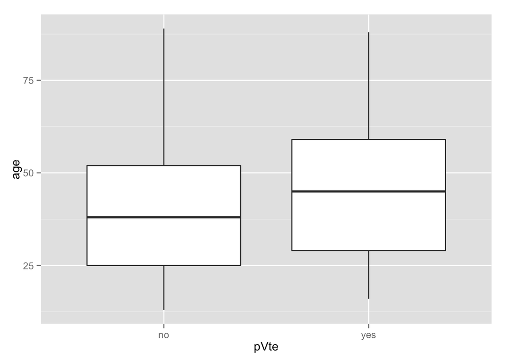

```r
ggplot(data=vte2, aes(pVte, age)) + geom_boxplot()
```

```r
glm <- glm(pVte ~ age, family = binomial(), data=vte2)
exp(summary(glm)$coeff[-1,1]) #Odds ratio
```

```
## [1] 1.016772
```

```r
summary(glm)$coeff[-1,4] #p-value
```

```
## [1] 0.001598673
```

```r
#iss--injury severity score
vte2 %>%
  filter(!is.na(iss)) %>%
  group_by(pVte) %>%
  summarise(mean_iss = mean(iss), sd_iss = sd(iss))
```

```
## Source: local data frame [2 x 3]
##
##     pVte mean_iss    sd_iss
##   (fctr)    (dbl)     (dbl)
## 1     no 11.82998  9.026236
## 2    yes 16.90722 10.038553
```

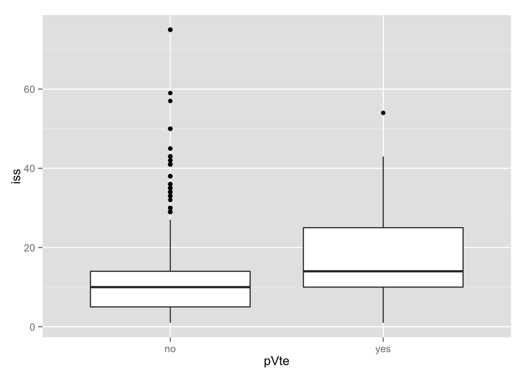

```r
ggplot(data=vte2, aes(pVte, iss)) + geom_boxplot()
```

```r
glm <- glm(pVte ~ iss, family = binomial(), data=vte2)
exp(summary(glm)$coeff[-1,1]) #Odds ratio
```

```
## [1] 1.040982
```

```r
summary(glm)$coeff[-1,4] #p-value
```

```
## [1] 1.890604e-07
```

```r
#hr--heart rate
vte2 %>%
  filter(!is.na(hr)) %>%
  group_by(pVte) %>%
  summarise(mean_hr = mean(hr), sd_iss = sd(hr))
```

```
## Source: local data frame [2 x 3]
##
##     pVte  mean_hr   sd_iss
##   (fctr)    (dbl)    (dbl)
## 1     no 91.70993 19.14827
## 2    yes 96.48454 26.42762
```

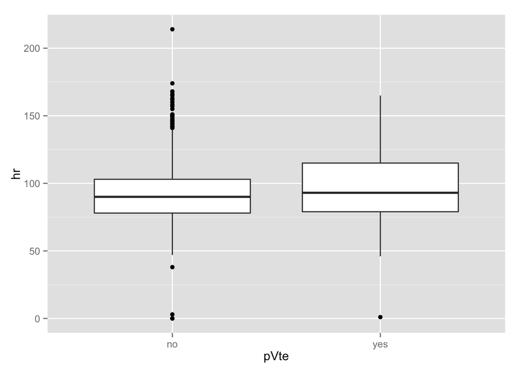

```r
ggplot(data=vte2, aes(pVte, hr)) + geom_boxplot()
```

```r
glm <- glm(pVte ~ hr, family = binomial(), data=vte2)
exp(summary(glm)$coeff[-1,1]) #Odds ratio
```

```
## [1] 1.011962
```

```r
summary(glm)$coeff[-1,4] #p-value
```

```
## [1] 0.01698705
```

```r
#sbp--systolic blood pressure
vte2 %>%
  filter(!is.na(sbp)) %>%
  group_by(pVte) %>%
  summarise(mean_sbp = mean(sbp), sd_sbp = sd(sbp))
```

```
## Source: local data frame [2 x 3]
##
##     pVte mean_sbp   sd_sbp
##   (fctr)    (dbl)    (dbl)
## 1     no 138.4245 25.72776
## 2    yes 132.4948 33.07067
```

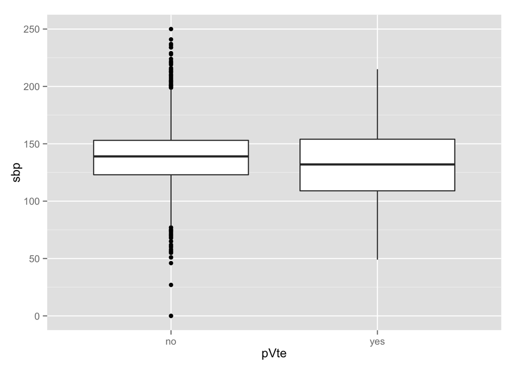

```r
ggplot(data=vte2, aes(pVte, sbp)) + geom_boxplot()
```

```r
glm <- glm(pVte ~ sbp, family = binomial(), data=vte2)
exp(summary(glm)$coeff[-1,1]) #Odds ratio
```

```
## [1] 0.9913209
```

```r
summary(glm)$coeff[-1,4] #p-value
```

```
## [1] 0.02643709
```

```r
#hemoglobin--
vte2 %>%
  filter(!is.na(hemoglobin)) %>%
  group_by(pVte) %>%
  summarise(mean_sbp = mean(hemoglobin), sd_sbp = sd(hemoglobin))
```

```
## Source: local data frame [2 x 3]
##
##     pVte mean_sbp   sd_sbp
##   (fctr)    (dbl)    (dbl)
## 1     no 11.97609 1.941821
## 2    yes 10.52268 1.797046
```

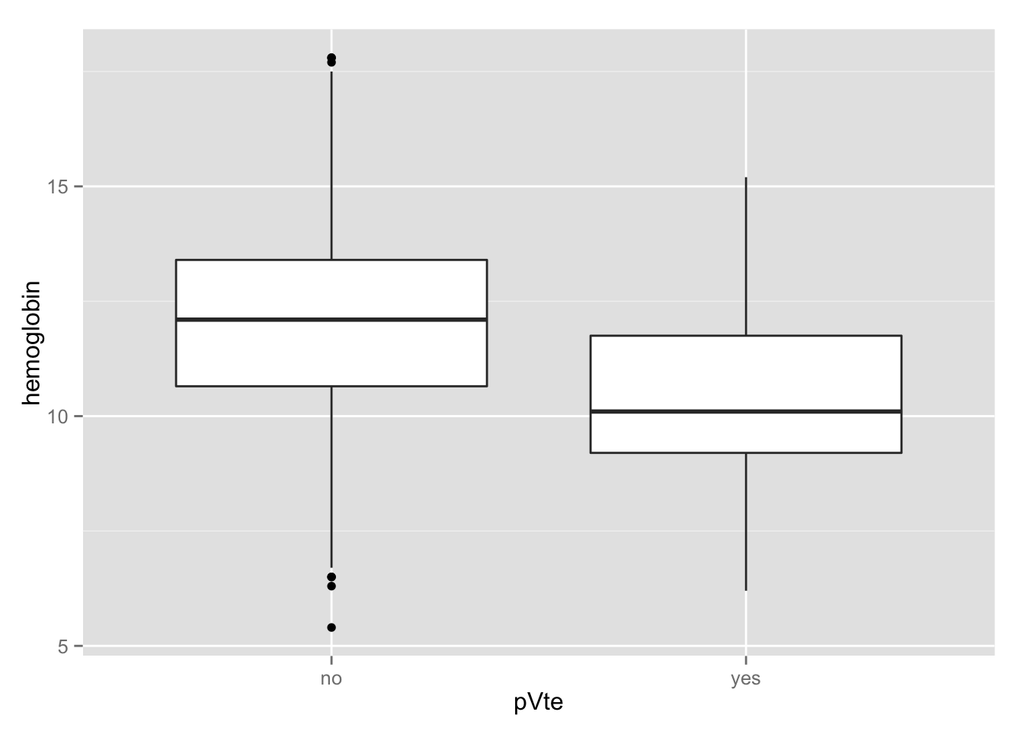

```r
ggplot(data=vte2, aes(pVte, hemoglobin)) + geom_boxplot()
```

```r
glm <- glm(pVte ~ hemoglobin, family = binomial(), data=vte2)
exp(summary(glm)$coeff[-1,1]) #Odds ratio
```

```
## [1] 0.683585
```

```r
summary(glm)$coeff[-1,4] #p-value
```

```
## [1] 2.582812e-12
```

```r
#platelets--
vte2 %>%
  filter(!is.na(platelets)) %>%
  group_by(pVte) %>%
  summarise(mean_platelets = mean(platelets), sd_platelets = sd(platelets))
```

```
## Source: local data frame [2 x 3]
##
##     pVte mean_platelets sd_platelets
##   (fctr)          (dbl)        (dbl)
## 1     no       207.7936     69.45797
## 2    yes       161.1134     69.01481
```

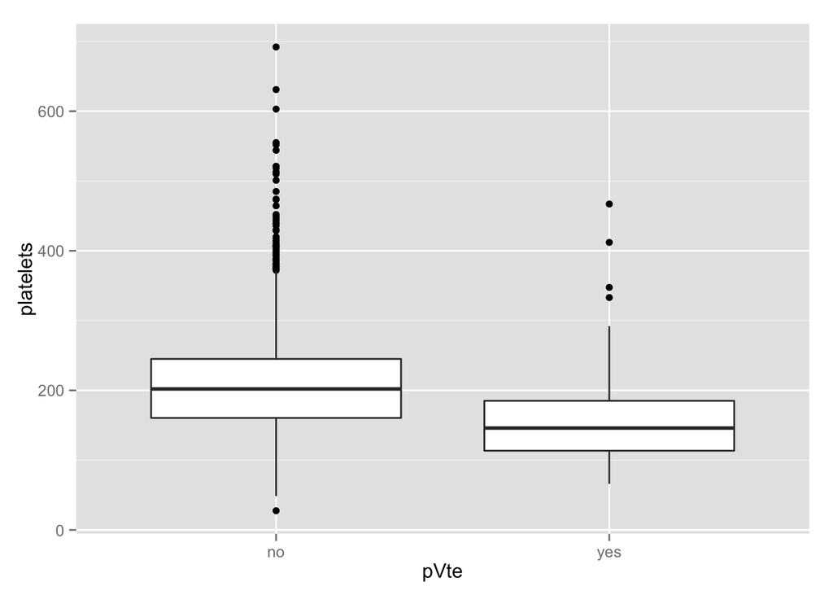

```r
ggplot(data=vte2, aes(pVte, platelets)) + geom_boxplot()
```

```r
glm <- glm(pVte ~ platelets, family = binomial(), data=vte2)
exp(summary(glm)$coeff[-1,1]) #Odds ratio
```

```
## [1] 0.9871654
```

```r
summary(glm)$coeff[-1,4] #p-value
```

```
## [1] 3.067505e-11
```

```r
#creatinine--
vte2 %>%
  filter(!is.na(creatinine)) %>%
  group_by(pVte) %>%
  summarise(mean_creatinine = mean(creatinine), sd_creatinine = sd(creatinine))
```

```
## Source: local data frame [2 x 3]
##
##     pVte mean_creatinine sd_creatinine
##   (fctr)           (dbl)         (dbl)
## 1     no       0.9382529     0.2402678
## 2    yes       0.9794845     0.2876598
```

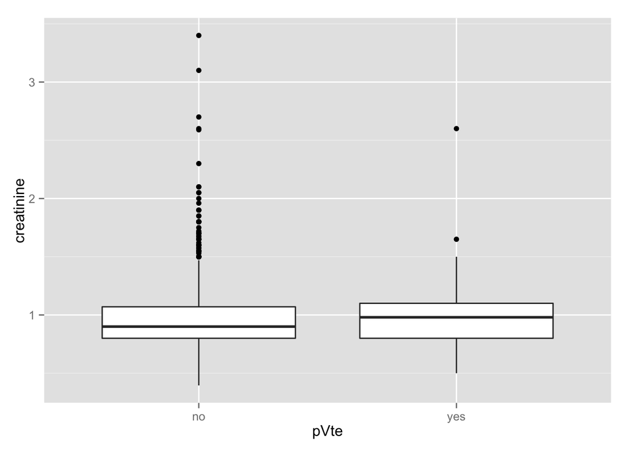

```r
ggplot(data=vte2, aes(pVte, creatinine)) + geom_boxplot()
```

```r
glm <- glm(pVte ~ creatinine, family = binomial(), data=vte2)
exp(summary(glm)$coeff[-1,1]) #Odds ratio
```

```
## [1] 1.846203
```

```r
summary(glm)$coeff[-1,4] #p-value
```

```
## [1] 0.0967599
```

```r
#Potential confounding variables associated with outcome in univariate analysis include:
#a_vent, aBlood, or24, pelvis, femur, lungContusion, bleed, vein, artery, icu
#race, age, iss, heart rate, systolic blood pressure, hemoglobin, platelets

#############################################
#Multivariable models
#############################################

#Start with full model
glm <- glm(pVte ~ platelets + hemoglobin + sbp + hr + iss + age + race + icu + artery + vein + bleed + lungContusion + pelvis + femur + or24 + aBlood + a_vent + earlyMiss + dCat, family = binomial(), data=vte2)
summary(glm)
```

```
##
## Call:
## glm(formula = pVte ~ platelets + hemoglobin + sbp + hr + iss +
##     age + race + icu + artery + vein + bleed + lungContusion +
##     pelvis + femur + or24 + aBlood + a_vent + earlyMiss + dCat,
##     family = binomial(), data = vte2)
##
## Deviance Residuals:
##     Min       1Q   Median       3Q      Max
## -1.5485  -0.2393  -0.1503  -0.0979   3.3326
##
## Coefficients:
##                   Estimate Std. Error z value Pr(>|z|)
## (Intercept)      -3.288317   1.192503  -2.757 0.005825 **
## platelets        -0.003186   0.002044  -1.558 0.119204
## hemoglobin       -0.193490   0.065761  -2.942 0.003258 **
## sbp               0.001022   0.003990   0.256 0.797819
## hr                0.003298   0.005360   0.615 0.538378
## iss              -0.012777   0.013865  -0.921 0.356807
## age               0.019305   0.006317   3.056 0.002244 **
## raceblack        -0.210484   0.244839  -0.860 0.389964
## raceasian         0.873642   0.645175   1.354 0.175699
## raceother        -1.598038   1.027415  -1.555 0.119851
## icuyes            0.565783   0.307337   1.841 0.065633 .
## arteryyes         0.457255   0.370349   1.235 0.216957
## veinyes           0.931117   0.546052   1.705 0.088161 .
## bleedyes          0.471791   0.345137   1.367 0.171636
## lungContusionyes  0.300196   0.349304   0.859 0.390114
## pelvisyes         0.414583   0.266380   1.556 0.119623
## femuryes          0.946625   0.249869   3.788 0.000152 ***
## or24yes           0.068736   0.262882   0.261 0.793728
## aBloodyes         0.291505   0.318829   0.914 0.360561
## a_ventyes         0.460402   0.303793   1.516 0.129643
## earlyMiss1-25 %  -0.719696   0.402782  -1.787 0.073968 .
## earlyMiss>25 %    0.430607   0.277500   1.552 0.120725
## dCat1-2 days      0.875042   0.306900   2.851 0.004355 **
## dCat2-3 days      1.268574   0.347503   3.651 0.000262 ***
## dCat>3 days       1.014338   0.365667   2.774 0.005538 **
## ---
## Signif. codes:  0 '***' 0.001 '**' 0.01 '*' 0.05 '.' 0.1 ' ' 1
##
## (Dispersion parameter for binomial family taken to be 1)
##
##     Null deviance: 861.70  on 3078  degrees of freedom
## Residual deviance: 691.01  on 3054  degrees of freedom
## AIC: 741.01
##
## Number of Fisher Scoring iterations: 7
```

```r
#remove variables in stepwise fashion, beginning with least signficant variables (i.e. highest p-value)

#remove or24
glm <- glm(pVte ~ platelets + hemoglobin + sbp + hr + iss + age + race + icu + artery + vein + bleed + lungContusion + pelvis + femur + aBlood + a_vent + earlyMiss + dCat, family = binomial(), data=vte2)
summary(glm)
```

```
##
## Call:
## glm(formula = pVte ~ platelets + hemoglobin + sbp + hr + iss +
##     age + race + icu + artery + vein + bleed + lungContusion +
##     pelvis + femur + aBlood + a_vent + earlyMiss + dCat, family = binomial(),
##     data = vte2)
##
## Deviance Residuals:
##     Min       1Q   Median       3Q      Max
## -1.5517  -0.2399  -0.1504  -0.0981   3.3479
##
## Coefficients:
##                    Estimate Std. Error z value Pr(>|z|)
## (Intercept)      -3.2253944  1.1684285  -2.760 0.005772 **
## platelets        -0.0031935  0.0020421  -1.564 0.117862
## hemoglobin       -0.1958934  0.0651047  -3.009 0.002622 **
## sbp               0.0009788  0.0039861   0.246 0.806024
## hr                0.0033526  0.0053618   0.625 0.531795
## iss              -0.0126512  0.0138641  -0.913 0.361496
## age               0.0189562  0.0061691   3.073 0.002121 **
## raceblack        -0.2066511  0.2443336  -0.846 0.397678
## raceasian         0.8796751  0.6448534   1.364 0.172521
## raceother        -1.6027570  1.0273750  -1.560 0.118748
## icuyes            0.5689198  0.3070497   1.853 0.063903 .
## arteryyes         0.4722484  0.3662686   1.289 0.197276
## veinyes           0.9417950  0.5452510   1.727 0.084119 .
## bleedyes          0.4753317  0.3452628   1.377 0.168598
## lungContusionyes  0.2968603  0.3489539   0.851 0.394928
## pelvisyes         0.4161434  0.2661789   1.563 0.117959
## femuryes          0.9436668  0.2496532   3.780 0.000157 ***
## aBloodyes         0.3033982  0.3156531   0.961 0.336464
## a_ventyes         0.4653918  0.3031956   1.535 0.124795
## earlyMiss1-25 %  -0.7206565  0.4028599  -1.789 0.073639 .
## earlyMiss>25 %    0.4323318  0.2775662   1.558 0.119333
## dCat1-2 days      0.8710203  0.3066358   2.841 0.004503 **
## dCat2-3 days      1.2662321  0.3473745   3.645 0.000267 ***
## dCat>3 days       1.0103477  0.3655561   2.764 0.005712 **
## ---
## Signif. codes:  0 '***' 0.001 '**' 0.01 '*' 0.05 '.' 0.1 ' ' 1
##
## (Dispersion parameter for binomial family taken to be 1)
##
##     Null deviance: 861.70  on 3078  degrees of freedom
## Residual deviance: 691.08  on 3055  degrees of freedom
## AIC: 739.08
##
## Number of Fisher Scoring iterations: 7
```

```r
#remove race
glm <- glm(pVte ~ platelets + hemoglobin + sbp + hr + iss + age + icu + artery + vein + bleed + lungContusion + pelvis + femur + aBlood + a_vent + earlyMiss + dCat, family = binomial(), data=vte2)
summary(glm)
```

```
##
## Call:
## glm(formula = pVte ~ platelets + hemoglobin + sbp + hr + iss +
##     age + icu + artery + vein + bleed + lungContusion + pelvis +
##     femur + aBlood + a_vent + earlyMiss + dCat, family = binomial(),
##     data = vte2)
##
## Deviance Residuals:
##     Min       1Q   Median       3Q      Max
## -1.5520  -0.2420  -0.1525  -0.1030   3.3955
##
## Coefficients:
##                    Estimate Std. Error z value Pr(>|z|)
## (Intercept)      -3.5170566  1.1403879  -3.084 0.002042 **
## platelets        -0.0033476  0.0020341  -1.646 0.099813 .
## hemoglobin       -0.1913556  0.0647848  -2.954 0.003140 **
## sbp               0.0008743  0.0039823   0.220 0.826229
## hr                0.0039412  0.0053667   0.734 0.462722
## iss              -0.0123191  0.0137662  -0.895 0.370850
## age               0.0214032  0.0058233   3.675 0.000237 ***
## icuyes            0.5764703  0.3061238   1.883 0.059683 .
## arteryyes         0.4388525  0.3623561   1.211 0.225854
## veinyes           0.9473623  0.5433166   1.744 0.081217 .
## bleedyes          0.4884742  0.3435692   1.422 0.155095
## lungContusionyes  0.2852038  0.3459372   0.824 0.409691
## pelvisyes         0.4188585  0.2639114   1.587 0.112486
## femuryes          0.9462010  0.2482122   3.812 0.000138 ***
## aBloodyes         0.3171815  0.3131066   1.013 0.311053
## a_ventyes         0.4302568  0.3007486   1.431 0.152539
## earlyMiss1-25 %  -0.6930679  0.3996389  -1.734 0.082876 .
## earlyMiss>25 %    0.4180784  0.2759928   1.515 0.129819
## dCat1-2 days      0.8631448  0.3058322   2.822 0.004768 **
## dCat2-3 days      1.2595899  0.3470788   3.629 0.000284 ***
## dCat>3 days       1.0003942  0.3649562   2.741 0.006123 **
## ---
## Signif. codes:  0 '***' 0.001 '**' 0.01 '*' 0.05 '.' 0.1 ' ' 1
##
## (Dispersion parameter for binomial family taken to be 1)
##
##     Null deviance: 861.70  on 3078  degrees of freedom
## Residual deviance: 697.34  on 3058  degrees of freedom
## AIC: 739.34
##
## Number of Fisher Scoring iterations: 7
```

```r
#remove SBP
glm <- glm(pVte ~ platelets + hemoglobin + hr + iss + age + icu + artery + vein + bleed + lungContusion + pelvis + femur + aBlood + a_vent + earlyMiss + dCat, family = binomial(), data=vte2)
summary(glm)
```

```
##
## Call:
## glm(formula = pVte ~ platelets + hemoglobin + hr + iss + age +
##     icu + artery + vein + bleed + lungContusion + pelvis + femur +
##     aBlood + a_vent + earlyMiss + dCat, family = binomial(),
##     data = vte2)
##
## Deviance Residuals:
##     Min       1Q   Median       3Q      Max
## -1.5552  -0.2418  -0.1523  -0.1032   3.3986
##
## Coefficients:
##                   Estimate Std. Error z value Pr(>|z|)
## (Intercept)      -3.426716   1.063468  -3.222 0.001272 **
## platelets        -0.003329   0.002033  -1.637 0.101571
## hemoglobin       -0.190345   0.064630  -2.945 0.003228 **
## hr                0.004057   0.005339   0.760 0.447369
## iss              -0.012142   0.013732  -0.884 0.376564
## age               0.021631   0.005733   3.773 0.000161 ***
## icuyes            0.570522   0.304905   1.871 0.061325 .
## arteryyes         0.437282   0.362101   1.208 0.227192
## veinyes           0.943014   0.543430   1.735 0.082687 .
## bleedyes          0.488548   0.343359   1.423 0.154780
## lungContusionyes  0.278767   0.344694   0.809 0.418666
## pelvisyes         0.412133   0.262155   1.572 0.115928
## femuryes          0.946833   0.248126   3.816 0.000136 ***
## aBloodyes         0.303103   0.306353   0.989 0.322473
## a_ventyes         0.431000   0.300787   1.433 0.151885
## earlyMiss1-25 %  -0.697686   0.399179  -1.748 0.080498 .
## earlyMiss>25 %    0.414973   0.275658   1.505 0.132223
## dCat1-2 days      0.861442   0.305726   2.818 0.004837 **
## dCat2-3 days      1.260268   0.347030   3.632 0.000282 ***
## dCat>3 days       0.997335   0.364633   2.735 0.006235 **
## ---
## Signif. codes:  0 '***' 0.001 '**' 0.01 '*' 0.05 '.' 0.1 ' ' 1
##
## (Dispersion parameter for binomial family taken to be 1)
##
##     Null deviance: 861.70  on 3078  degrees of freedom
## Residual deviance: 697.39  on 3059  degrees of freedom
## AIC: 737.39
##
## Number of Fisher Scoring iterations: 7
```

```r
#remove HR
glm <- glm(pVte ~ platelets + hemoglobin + iss + age + icu + artery + vein + bleed + lungContusion + pelvis + femur + aBlood + a_vent + earlyMiss + dCat, family = binomial(), data=vte2)
summary(glm)
```

```
##
## Call:
## glm(formula = pVte ~ platelets + hemoglobin + iss + age + icu +
##     artery + vein + bleed + lungContusion + pelvis + femur +
##     aBlood + a_vent + earlyMiss + dCat, family = binomial(),
##     data = vte2)
##
## Deviance Residuals:
##     Min       1Q   Median       3Q      Max
## -1.5983  -0.2431  -0.1536  -0.1026   3.3700
##
## Coefficients:
##                   Estimate Std. Error z value Pr(>|z|)
## (Intercept)      -3.020673   0.917714  -3.292 0.000996 ***
## platelets        -0.003376   0.002041  -1.654 0.098194 .
## hemoglobin       -0.190954   0.064658  -2.953 0.003144 **
## iss              -0.012382   0.013739  -0.901 0.367482
## age               0.020998   0.005671   3.703 0.000213 ***
## icuyes            0.580600   0.304624   1.906 0.056656 .
## arteryyes         0.413593   0.360588   1.147 0.251382
## veinyes           0.984924   0.540476   1.822 0.068405 .
## bleedyes          0.489622   0.342237   1.431 0.152530
## lungContusionyes  0.284652   0.344542   0.826 0.408705
## pelvisyes         0.403939   0.261698   1.544 0.122701
## femuryes          0.937414   0.248003   3.780 0.000157 ***
## aBloodyes         0.343304   0.301103   1.140 0.254222
## a_ventyes         0.463210   0.297543   1.557 0.119522
## earlyMiss1-25 %  -0.700847   0.399494  -1.754 0.079373 .
## earlyMiss>25 %    0.421398   0.275547   1.529 0.126187
## dCat1-2 days      0.860967   0.305856   2.815 0.004879 **
## dCat2-3 days      1.270119   0.346605   3.664 0.000248 ***
## dCat>3 days       1.005509   0.364133   2.761 0.005756 **
## ---
## Signif. codes:  0 '***' 0.001 '**' 0.01 '*' 0.05 '.' 0.1 ' ' 1
##
## (Dispersion parameter for binomial family taken to be 1)
##
##     Null deviance: 861.70  on 3078  degrees of freedom
## Residual deviance: 697.96  on 3060  degrees of freedom
## AIC: 735.96
##
## Number of Fisher Scoring iterations: 7
```

```r
#remove lungContusion
glm <- glm(pVte ~ platelets + hemoglobin + iss + age + icu + artery + vein + bleed + pelvis + femur + aBlood + a_vent + earlyMiss + dCat, family = binomial(), data=vte2)
summary(glm)
```

```
##
## Call:
## glm(formula = pVte ~ platelets + hemoglobin + iss + age + icu +
##     artery + vein + bleed + pelvis + femur + aBlood + a_vent +
##     earlyMiss + dCat, family = binomial(), data = vte2)
##
## Deviance Residuals:
##     Min       1Q   Median       3Q      Max
## -1.5073  -0.2453  -0.1534  -0.1026   3.3643
##
## Coefficients:
##                  Estimate Std. Error z value Pr(>|z|)
## (Intercept)     -3.011598   0.915955  -3.288 0.001009 **
## platelets       -0.003364   0.002041  -1.648 0.099302 .
## hemoglobin      -0.191348   0.064592  -2.962 0.003053 **
## iss             -0.008793   0.012760  -0.689 0.490743
## age              0.020342   0.005601   3.632 0.000281 ***
## icuyes           0.590060   0.304242   1.939 0.052447 .
## arteryyes        0.386089   0.358272   1.078 0.281193
## veinyes          0.979035   0.536806   1.824 0.068180 .
## bleedyes         0.469827   0.340686   1.379 0.167876
## pelvisyes        0.402284   0.261005   1.541 0.123246
## femuryes         0.929801   0.246847   3.767 0.000165 ***
## aBloodyes        0.354665   0.300777   1.179 0.238334
## a_ventyes        0.453669   0.297570   1.525 0.127364
## earlyMiss1-25 % -0.686102   0.398971  -1.720 0.085491 .
## earlyMiss>25 %   0.435509   0.274208   1.588 0.112232
## dCat1-2 days     0.868482   0.305794   2.840 0.004510 **
## dCat2-3 days     1.279264   0.345970   3.698 0.000218 ***
## dCat>3 days      1.008083   0.364649   2.765 0.005700 **
## ---
## Signif. codes:  0 '***' 0.001 '**' 0.01 '*' 0.05 '.' 0.1 ' ' 1
##
## (Dispersion parameter for binomial family taken to be 1)
##
##     Null deviance: 861.70  on 3078  degrees of freedom
## Residual deviance: 698.63  on 3061  degrees of freedom
## AIC: 734.63
##
## Number of Fisher Scoring iterations: 7
```

```r
#remove iss
glm <- glm(pVte ~ platelets + hemoglobin + age + icu + artery + vein + bleed + pelvis + femur + aBlood + a_vent + earlyMiss + dCat, family = binomial(), data=vte2)
summary(glm)
```

```
##
## Call:
## glm(formula = pVte ~ platelets + hemoglobin + age + icu + artery +
##     vein + bleed + pelvis + femur + aBlood + a_vent + earlyMiss +
##     dCat, family = binomial(), data = vte2)
##
## Deviance Residuals:
##     Min       1Q   Median       3Q      Max
## -1.5320  -0.2445  -0.1524  -0.1023   3.3618
##
## Coefficients:
##                  Estimate Std. Error z value Pr(>|z|)
## (Intercept)     -3.104926   0.906048  -3.427 0.000611 ***
## platelets       -0.003328   0.002038  -1.633 0.102487
## hemoglobin      -0.190840   0.064588  -2.955 0.003130 **
## age              0.020665   0.005577   3.705 0.000211 ***
## icuyes           0.555842   0.300078   1.852 0.063979 .
## arteryyes        0.365664   0.356337   1.026 0.304810
## veinyes          1.009500   0.533896   1.891 0.058649 .
## bleedyes         0.419802   0.332396   1.263 0.206606
## pelvisyes        0.387213   0.259384   1.493 0.135485
## femuryes         0.911425   0.244622   3.726 0.000195 ***
## aBloodyes        0.336413   0.300136   1.121 0.262344
## a_ventyes        0.427284   0.295944   1.444 0.148796
## earlyMiss1-25 % -0.701636   0.398226  -1.762 0.078085 .
## earlyMiss>25 %   0.433095   0.274151   1.580 0.114160
## dCat1-2 days     0.859860   0.305548   2.814 0.004891 **
## dCat2-3 days     1.257426   0.344776   3.647 0.000265 ***
## dCat>3 days      0.946216   0.354225   2.671 0.007557 **
## ---
## Signif. codes:  0 '***' 0.001 '**' 0.01 '*' 0.05 '.' 0.1 ' ' 1
##
## (Dispersion parameter for binomial family taken to be 1)
##
##     Null deviance: 861.70  on 3078  degrees of freedom
## Residual deviance: 699.11  on 3062  degrees of freedom
## AIC: 733.11
##
## Number of Fisher Scoring iterations: 7
```

```r
#remove artery
glm <- glm(pVte ~ platelets + hemoglobin + age + icu + vein + bleed + pelvis + femur + aBlood + a_vent + earlyMiss + dCat, family = binomial(), data=vte2)
summary(glm)
```

```
##
## Call:
## glm(formula = pVte ~ platelets + hemoglobin + age + icu + vein +
##     bleed + pelvis + femur + aBlood + a_vent + earlyMiss + dCat,
##     family = binomial(), data = vte2)
##
## Deviance Residuals:
##     Min       1Q   Median       3Q      Max
## -1.5052  -0.2439  -0.1518  -0.1018   3.3637
##
## Coefficients:
##                  Estimate Std. Error z value Pr(>|z|)
## (Intercept)     -3.019678   0.899781  -3.356 0.000791 ***
## platelets       -0.003481   0.002036  -1.710 0.087238 .
## hemoglobin      -0.195057   0.064324  -3.032 0.002426 **
## age              0.020391   0.005559   3.668 0.000244 ***
## icuyes           0.559210   0.300061   1.864 0.062370 .
## veinyes          1.199016   0.497009   2.412 0.015845 *
## bleedyes         0.463356   0.327138   1.416 0.156660
## pelvisyes        0.404966   0.257886   1.570 0.116339
## femuryes         0.909657   0.244339   3.723 0.000197 ***
## aBloodyes        0.394011   0.293011   1.345 0.178723
## a_ventyes        0.437730   0.295381   1.482 0.138363
## earlyMiss1-25 % -0.687552   0.396967  -1.732 0.083271 .
## earlyMiss>25 %   0.429114   0.273752   1.568 0.116991
## dCat1-2 days     0.857596   0.305647   2.806 0.005019 **
## dCat2-3 days     1.277072   0.343700   3.716 0.000203 ***
## dCat>3 days      0.981124   0.351215   2.794 0.005214 **
## ---
## Signif. codes:  0 '***' 0.001 '**' 0.01 '*' 0.05 '.' 0.1 ' ' 1
##
## (Dispersion parameter for binomial family taken to be 1)
##
##     Null deviance: 861.70  on 3078  degrees of freedom
## Residual deviance: 700.13  on 3063  degrees of freedom
## AIC: 732.13
##
## Number of Fisher Scoring iterations: 7
```

```r
#remove aBlood
glm <- glm(pVte ~ platelets + hemoglobin + age + icu + vein + bleed + pelvis + femur + a_vent + earlyMiss + dCat, family = binomial(), data=vte2)
summary(glm)
```

```
##
## Call:
## glm(formula = pVte ~ platelets + hemoglobin + age + icu + vein +
##     bleed + pelvis + femur + a_vent + earlyMiss + dCat, family = binomial(),
##     data = vte2)
##
## Deviance Residuals:
##     Min       1Q   Median       3Q      Max
## -1.4472  -0.2481  -0.1523  -0.1013   3.3621
##
## Coefficients:
##                  Estimate Std. Error z value Pr(>|z|)
## (Intercept)     -2.934506   0.895447  -3.277 0.001049 **
## platelets       -0.004003   0.002003  -1.999 0.045615 *
## hemoglobin      -0.193913   0.064224  -3.019 0.002533 **
## age              0.020331   0.005541   3.669 0.000243 ***
## icuyes           0.604157   0.297277   2.032 0.042123 *
## veinyes          1.272837   0.494033   2.576 0.009983 **
## bleedyes         0.482933   0.326188   1.481 0.138730
## pelvisyes        0.436131   0.256008   1.704 0.088459 .
## femuryes         0.917273   0.243608   3.765 0.000166 ***
## a_ventyes        0.512031   0.288572   1.774 0.076003 .
## earlyMiss1-25 % -0.694325   0.396823  -1.750 0.080168 .
## earlyMiss>25 %   0.417465   0.272877   1.530 0.126051
## dCat1-2 days     0.867064   0.304983   2.843 0.004469 **
## dCat2-3 days     1.295711   0.342438   3.784 0.000154 ***
## dCat>3 days      0.990411   0.349926   2.830 0.004650 **
## ---
## Signif. codes:  0 '***' 0.001 '**' 0.01 '*' 0.05 '.' 0.1 ' ' 1
##
## (Dispersion parameter for binomial family taken to be 1)
##
##     Null deviance: 861.7  on 3078  degrees of freedom
## Residual deviance: 701.9  on 3064  degrees of freedom
## AIC: 731.9
##
## Number of Fisher Scoring iterations: 7
```

```r
#remove bleed
glm <- glm(pVte ~ platelets + hemoglobin + age + icu + vein + pelvis + femur + a_vent + earlyMiss + dCat, family = binomial(), data=vte2)
summary(glm)
```

```
##
## Call:
## glm(formula = pVte ~ platelets + hemoglobin + age + icu + vein +
##     pelvis + femur + a_vent + earlyMiss + dCat, family = binomial(),
##     data = vte2)
##
## Deviance Residuals:
##     Min       1Q   Median       3Q      Max
## -1.5092  -0.2501  -0.1540  -0.1020   3.3564
##
## Coefficients:
##                  Estimate Std. Error z value Pr(>|z|)
## (Intercept)     -2.902027   0.892486  -3.252 0.001147 **
## platelets       -0.004094   0.002011  -2.036 0.041764 *
## hemoglobin      -0.192310   0.063983  -3.006 0.002650 **
## age              0.019694   0.005507   3.576 0.000348 ***
## icuyes           0.627615   0.296334   2.118 0.034181 *
## veinyes          1.291699   0.493939   2.615 0.008920 **
## pelvisyes        0.475429   0.254533   1.868 0.061783 .
## femuryes         0.889074   0.242089   3.673 0.000240 ***
## a_ventyes        0.527046   0.287828   1.831 0.067083 .
## earlyMiss1-25 % -0.674140   0.395702  -1.704 0.088445 .
## earlyMiss>25 %   0.422505   0.272594   1.550 0.121155
## dCat1-2 days     0.888252   0.304475   2.917 0.003530 **
## dCat2-3 days     1.342452   0.340241   3.946 7.96e-05 ***
## dCat>3 days      1.049700   0.346361   3.031 0.002440 **
## ---
## Signif. codes:  0 '***' 0.001 '**' 0.01 '*' 0.05 '.' 0.1 ' ' 1
##
## (Dispersion parameter for binomial family taken to be 1)
##
##     Null deviance: 861.70  on 3078  degrees of freedom
## Residual deviance: 703.95  on 3065  degrees of freedom
## AIC: 731.95
##
## Number of Fisher Scoring iterations: 7
```

```r
#remove pelvis
glm <- glm(pVte ~ platelets + hemoglobin + age + icu + vein + femur + a_vent + earlyMiss + dCat, family = binomial(), data=vte2)
summary(glm)
```

```
##
## Call:
## glm(formula = pVte ~ platelets + hemoglobin + age + icu + vein +
##     femur + a_vent + earlyMiss + dCat, family = binomial(), data = vte2)
##
## Deviance Residuals:
##     Min       1Q   Median       3Q      Max
## -1.3942  -0.2526  -0.1540  -0.1007   3.4001
##
## Coefficients:
##                  Estimate Std. Error z value Pr(>|z|)
## (Intercept)     -2.745446   0.880159  -3.119 0.001813 **
## platelets       -0.004472   0.002002  -2.233 0.025545 *
## hemoglobin      -0.197418   0.063317  -3.118 0.001821 **
## age              0.019443   0.005488   3.543 0.000396 ***
## icuyes           0.686551   0.295488   2.323 0.020155 *
## veinyes          1.295148   0.486539   2.662 0.007769 **
## femuryes         0.935558   0.240526   3.890 0.000100 ***
## a_ventyes        0.505549   0.287540   1.758 0.078716 .
## earlyMiss1-25 % -0.633150   0.392249  -1.614 0.106494
## earlyMiss>25 %   0.447370   0.270825   1.652 0.098560 .
## dCat1-2 days     0.903276   0.304143   2.970 0.002979 **
## dCat2-3 days     1.402359   0.337793   4.152  3.3e-05 ***
## dCat>3 days      1.128496   0.341307   3.306 0.000945 ***
## ---
## Signif. codes:  0 '***' 0.001 '**' 0.01 '*' 0.05 '.' 0.1 ' ' 1
##
## (Dispersion parameter for binomial family taken to be 1)
##
##     Null deviance: 861.70  on 3078  degrees of freedom
## Residual deviance: 707.28  on 3066  degrees of freedom
## AIC: 733.28
##
## Number of Fisher Scoring iterations: 7
```

```r
#remove a_vent
glm <- glm(pVte ~ platelets + hemoglobin + age + icu + vein + femur + earlyMiss + dCat, family = binomial(), data=vte2)
summary(glm)
```

```
##
## Call:
## glm(formula = pVte ~ platelets + hemoglobin + age + icu + vein +
##     femur + earlyMiss + dCat, family = binomial(), data = vte2)
##
## Deviance Residuals:
##     Min       1Q   Median       3Q      Max
## -1.3094  -0.2544  -0.1556  -0.1024   3.3909
##
## Coefficients:
##                  Estimate Std. Error z value Pr(>|z|)
## (Intercept)     -2.625920   0.875266  -3.000 0.002699 **
## platelets       -0.004999   0.002007  -2.491 0.012752 *
## hemoglobin      -0.189796   0.062864  -3.019 0.002535 **
## age              0.017930   0.005379   3.333 0.000859 ***
## icuyes           0.938910   0.250398   3.750 0.000177 ***
## veinyes          1.297346   0.483387   2.684 0.007278 **
## femuryes         0.928194   0.239571   3.874 0.000107 ***
## earlyMiss1-25 % -0.609213   0.390653  -1.559 0.118884
## earlyMiss>25 %   0.438498   0.270802   1.619 0.105392
## dCat1-2 days     0.881409   0.303828   2.901 0.003720 **
## dCat2-3 days     1.395369   0.337527   4.134 3.56e-05 ***
## dCat>3 days      1.164480   0.340751   3.417 0.000632 ***
## ---
## Signif. codes:  0 '***' 0.001 '**' 0.01 '*' 0.05 '.' 0.1 ' ' 1
##
## (Dispersion parameter for binomial family taken to be 1)
##
##     Null deviance: 861.70  on 3078  degrees of freedom
## Residual deviance: 710.43  on 3067  degrees of freedom
## AIC: 734.43
##
## Number of Fisher Scoring iterations: 7
```

```r
#test parameters for the early miss variable
glm1 <- glm(pVte ~ platelets + hemoglobin + age + icu + vein + femur + earlyMiss + dCat, family = binomial(), data=vte2)
glm2 <- glm(pVte ~ platelets + hemoglobin + age + icu + vein + femur + dCat, family = binomial(), data=vte2)
lrtest(glm1, glm2)
```

```
## Likelihood ratio test
##
## Model 1: pVte ~ platelets + hemoglobin + age + icu + vein + femur + earlyMiss +
##     dCat
## Model 2: pVte ~ platelets + hemoglobin + age + icu + vein + femur + dCat
##   #Df  LogLik Df  Chisq Pr(>Chisq)
## 1  12 -355.22
## 2  10 -358.41 -2 6.3767    0.04124 *
## ---
## Signif. codes:  0 '***' 0.001 '**' 0.01 '*' 0.05 '.' 0.1 ' ' 1
```

```r
##Early miss variable signficant at 0.05 level

############################################
###We have arrived at the final model###
###########################################
summary(glm1)
```

```
##
## Call:
## glm(formula = pVte ~ platelets + hemoglobin + age + icu + vein +
##     femur + earlyMiss + dCat, family = binomial(), data = vte2)
##
## Deviance Residuals:
##     Min       1Q   Median       3Q      Max
## -1.3094  -0.2544  -0.1556  -0.1024   3.3909
##
## Coefficients:
##                  Estimate Std. Error z value Pr(>|z|)
## (Intercept)     -2.625920   0.875266  -3.000 0.002699 **
## platelets       -0.004999   0.002007  -2.491 0.012752 *
## hemoglobin      -0.189796   0.062864  -3.019 0.002535 **
## age              0.017930   0.005379   3.333 0.000859 ***
## icuyes           0.938910   0.250398   3.750 0.000177 ***
## veinyes          1.297346   0.483387   2.684 0.007278 **
## femuryes         0.928194   0.239571   3.874 0.000107 ***
## earlyMiss1-25 % -0.609213   0.390653  -1.559 0.118884
## earlyMiss>25 %   0.438498   0.270802   1.619 0.105392
## dCat1-2 days     0.881409   0.303828   2.901 0.003720 **
## dCat2-3 days     1.395369   0.337527   4.134 3.56e-05 ***
## dCat>3 days      1.164480   0.340751   3.417 0.000632 ***
## ---
## Signif. codes:  0 '***' 0.001 '**' 0.01 '*' 0.05 '.' 0.1 ' ' 1
##
## (Dispersion parameter for binomial family taken to be 1)
##
##     Null deviance: 861.70  on 3078  degrees of freedom
## Residual deviance: 710.43  on 3067  degrees of freedom
## AIC: 734.43
##
## Number of Fisher Scoring iterations: 7
```

```r
exp(summary(glm1)$coeff[-1,1]) #Odds ratio
```

```
##       platelets      hemoglobin             age          icuyes
##       0.9950139       0.8271275       1.0180916       2.5571935
##         veinyes        femuryes earlyMiss1-25 %  earlyMiss>25 %
##       3.6595695       2.5299367       0.5437786       1.5503766
##    dCat1-2 days    dCat2-3 days     dCat>3 days
##       2.4142999       4.0364625       3.2042556
```

```r
##Re-run model, using the log transformed version of the delay variable
glm <- glm(pVte ~ platelets + hemoglobin + age + icu + vein + femur + earlyMiss + lnDelay, family = binomial(), data=vte2)
glm2 <- glm(pVte ~ platelets + hemoglobin + age + icu + vein + femur + lnDelay, family = binomial(), data=vte2)
lrtest(glm, glm2)
```

```
## Likelihood ratio test
##
## Model 1: pVte ~ platelets + hemoglobin + age + icu + vein + femur + earlyMiss +
##     lnDelay
## Model 2: pVte ~ platelets + hemoglobin + age + icu + vein + femur + lnDelay
##   #Df  LogLik Df  Chisq Pr(>Chisq)
## 1  10 -360.15
## 2   8 -363.25 -2 6.1898    0.04528 *
## ---
## Signif. codes:  0 '***' 0.001 '**' 0.01 '*' 0.05 '.' 0.1 ' ' 1
```

```r
summary(glm)
```

```
##
## Call:
## glm(formula = pVte ~ platelets + hemoglobin + age + icu + vein +
##     femur + earlyMiss + lnDelay, family = binomial(), data = vte2)
##
## Deviance Residuals:
##     Min       1Q   Median       3Q      Max
## -1.3483  -0.2505  -0.1601  -0.1130   3.2736
##
## Coefficients:
##                  Estimate Std. Error z value Pr(>|z|)
## (Intercept)     -2.087581   0.853386  -2.446 0.014436 *
## platelets       -0.005183   0.002012  -2.576 0.010004 *
## hemoglobin      -0.179964   0.062771  -2.867 0.004144 **
## age              0.017911   0.005320   3.367 0.000761 ***
## icuyes           0.899486   0.251391   3.578 0.000346 ***
## veinyes          1.257382   0.470895   2.670 0.007581 **
## femuryes         0.936293   0.238085   3.933  8.4e-05 ***
## earlyMiss1-25 % -0.630752   0.390038  -1.617 0.105845
## earlyMiss>25 %   0.398746   0.268412   1.486 0.137392
## lnDelay          0.441824   0.131198   3.368 0.000758 ***
## ---
## Signif. codes:  0 '***' 0.001 '**' 0.01 '*' 0.05 '.' 0.1 ' ' 1
##
## (Dispersion parameter for binomial family taken to be 1)
##
##     Null deviance: 861.70  on 3078  degrees of freedom
## Residual deviance: 720.31  on 3069  degrees of freedom
## AIC: 740.31
##
## Number of Fisher Scoring iterations: 7
```

```r
exp(summary(glm)$coeff[-1,1]) #Odds ratio
```

```
##       platelets      hemoglobin             age          icuyes
##       0.9948305       0.8353000       1.0180727       2.4583381
##         veinyes        femuryes earlyMiss1-25 %  earlyMiss>25 %
##       3.5162023       2.5505090       0.5321916       1.4899548
##         lnDelay
##       1.5555422
```

```r
##Results are similar using the log transformed delay variable
```

### Discussion

VTE continues to be an important complication after traumatic injury. Although prophylaxis with low molecular weight heparin agents such as enoxaparin is effective, the rate of VTE remains unacceptably high. Understanding factors that lead to prophylaxis failure is thus of great importance. In this study, we examined the impact of various prophylaxis administration patterns on VTE risk and observed that the time to initiation was a major factor determining VTE risk. In addition, failing to administer scheduled doses was also a risk factor, but only during the early time period after injury. Together, these data suggest that prophylaxis exposure is most important during the early stages of recovery from injury. Importantly, these risk factors are potentialy modifiable. Future research should focus on elucidating the reasons for delayed administration. These data could inform the design of clinical decision support tools that facilitate timely prophylaxis administration.

### References

1. Centers for Disease Control and Prevention: Injury and Violence statistics. Accessed September 9th, 2013. Available at: http://www.cdc.gov/injury/overview/data.html
2. National Trauma Databank Annual Report. Accessed August 17, 2013. Available at: http://www.facs.org/trauma/ntdb/pdf/ntdb-annual-report-2012.pdf
3. Acosta JA, Yang JC, Winchell RJ, Simons RK, Fortlage DA, Hollingsworth-Fridlund P, Hoyt DB. Lethal injuries and time to death in a level I trauma center. J Am Coll Surg. 1998; 186: 528-33. PMID: 9583692
4. Gould MK, Garcia DA, Wren SM, Karanicolas PJ, Arcelus JI, Heit JA, Samama CM. Prevention of VTE in Nonorthopedic Surgical Patients: Antithrombotic Therapy and Prevention of Thrombosis, 9th ed: American College of Chest Physicians Evidence-Based Clinical Practice Guidelines. CHEST 2012; 141(Suppl):e227S–e277S. PMID: 22315263
5. Rogers FB, Cipolle MD, Velmahos G, Rozycki G, Luchette FA. Practice management guidelines for the prevention of venous thromboembolism in trauma patients: the EAST practice management guidelines work group. J Trauma. 2002; 53: 142-64. PMID: 12131409
6. Velmahos GC, Kern J, Chan LS, Oder D, Murray JA, Shekelle P. Prevention of venous thromboembolism after injury: an evidence-based report–part I: analysis of risk factors and evaluation of the role of vena caval filters. J Trauma. 2000; 49: 132-8. PMID: 10912869
7. Barrera LM, Perel P, Ker K, Cirocchi R, Farinella E, Morales Uribe CH. Cochrane Database Syst Rev. 2013; 3: CD008303. doi: 10.1002/14651858.CD008303.pub2. PMID: 23543562